```r
library(ggplot2)
library(MASS)
library(grid)
library(gridExtra)
library(reshape2)
```

## Boxplot

plot them alongside each other

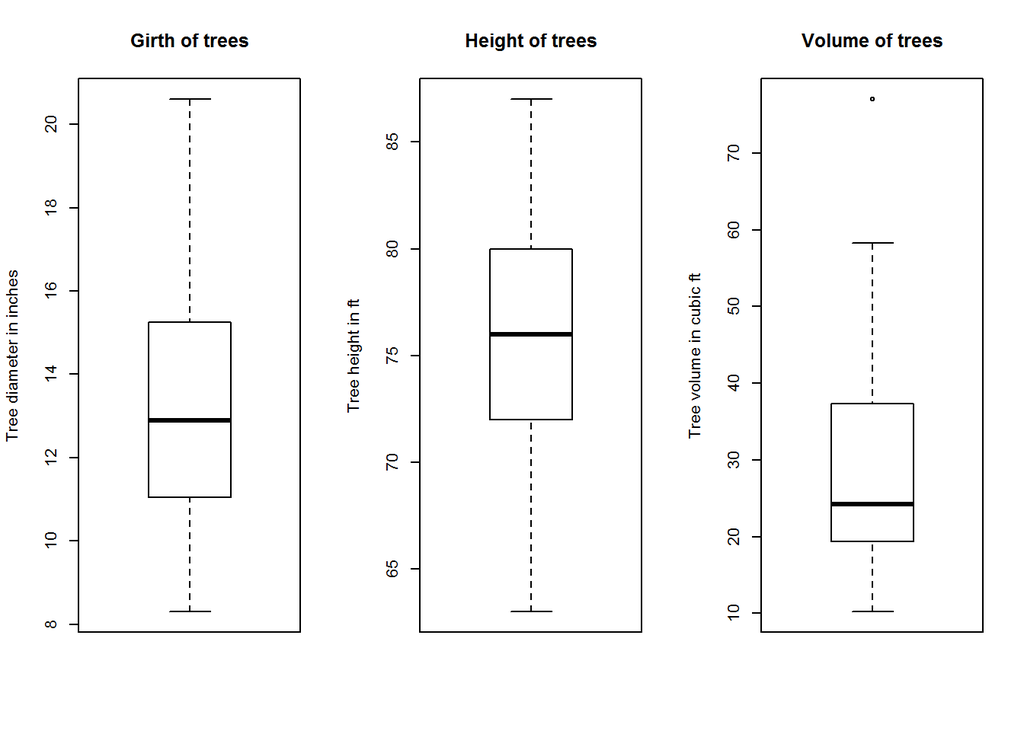

```r
op<-par(no.readonly = TRUE)
par(mfrow=c(1,3))
boxplot(trees$Girth)
title(main="Girth of trees",ylab="Tree diameter in inches")
boxplot(trees$Height)
title(main="Height of trees",ylab="Tree height in ft")
boxplot(trees$Volume)
title(main="Volume of trees",ylab="Tree volume in cubic ft")
```

```r
par(op)
```

plotting them horizontally

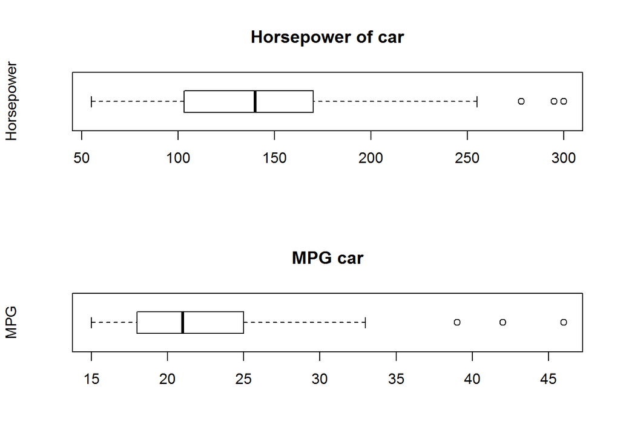

```r
op<-par(no.readonly = TRUE)
par(mfrow = c(2,1))
boxplot(Cars93$Horsepower, horizontal = T)
title(main="Horsepower of car",ylab="Horsepower")
boxplot(Cars93$MPG.city, horizontal = T)
title(main="MPG car",ylab="MPG")
```

```r
par(op)
```

```r
head(trees)
```

```
##   Girth Height Volume
## 1   8.3     70   10.3
## 2   8.6     65   10.3
## 3   8.8     63   10.2
## 4  10.5     72   16.4
## 5  10.7     81   18.8
## 6  10.8     83   19.7
```

Plotting boxplot of all columns in one graph

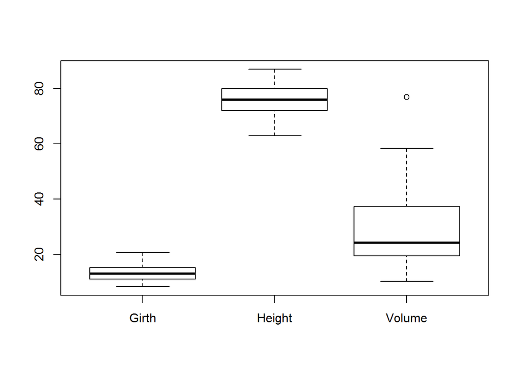

```r
boxplot(trees)
```

combining different boxplot in one graph

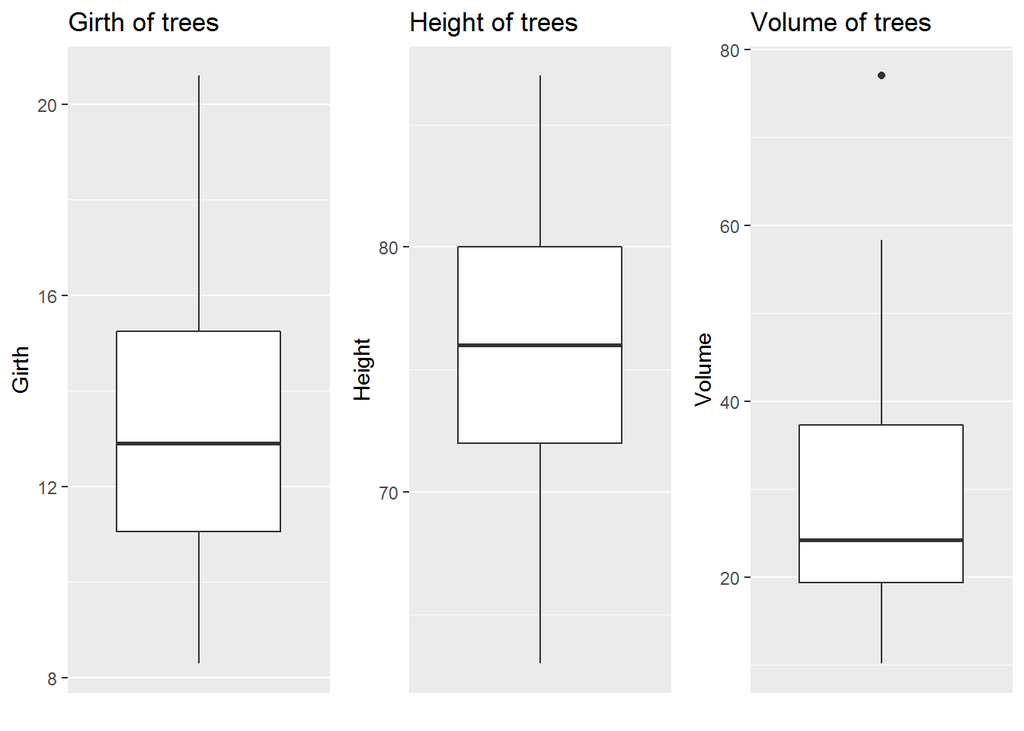

```r
p1 <- ggplot() +
  geom_boxplot(data = trees, aes(factor(0), Girth)) +
  scale_x_discrete(breaks = NULL) +
  xlab(" ") +
  ggtitle("Girth of trees")

p2 <- ggplot() +
  geom_boxplot(data = trees, aes(factor(0), Height)) +
  scale_x_discrete(breaks = NULL) +
  xlab(" ") +
  ggtitle("Height of trees")

p3 <- ggplot() +
  geom_boxplot(data = trees, aes(factor(0), Volume)) +
  scale_x_discrete(breaks = NULL) +
  xlab(" ") +
  ggtitle("Volume of trees")

grid.arrange(p1,p2,p3,ncol=3)
```

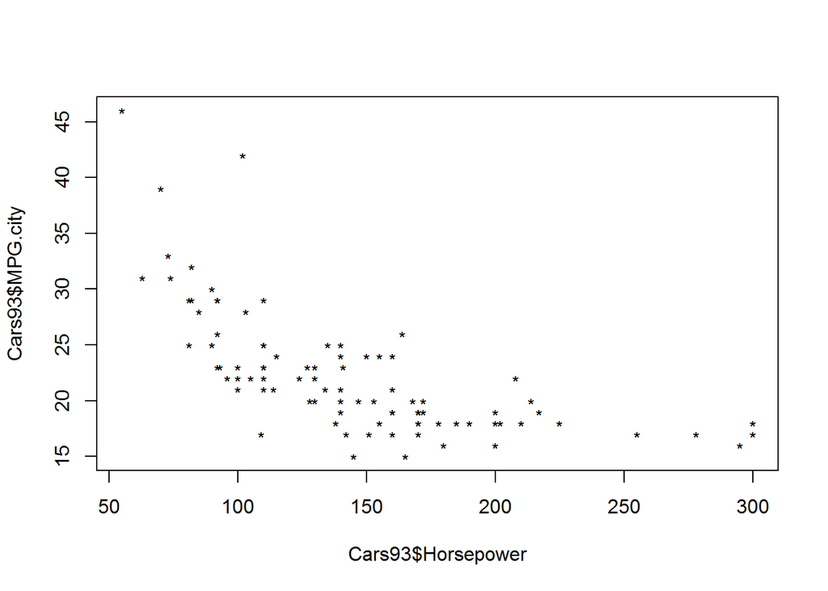

```r
# Scatter plot
plot(Cars93$Horsepower, Cars93$MPG.city, type = 'p', pch = "*", cex = 0.9)
```

p -points

l -lines

o - plot points and lines

## scatter plots using the trees data set.

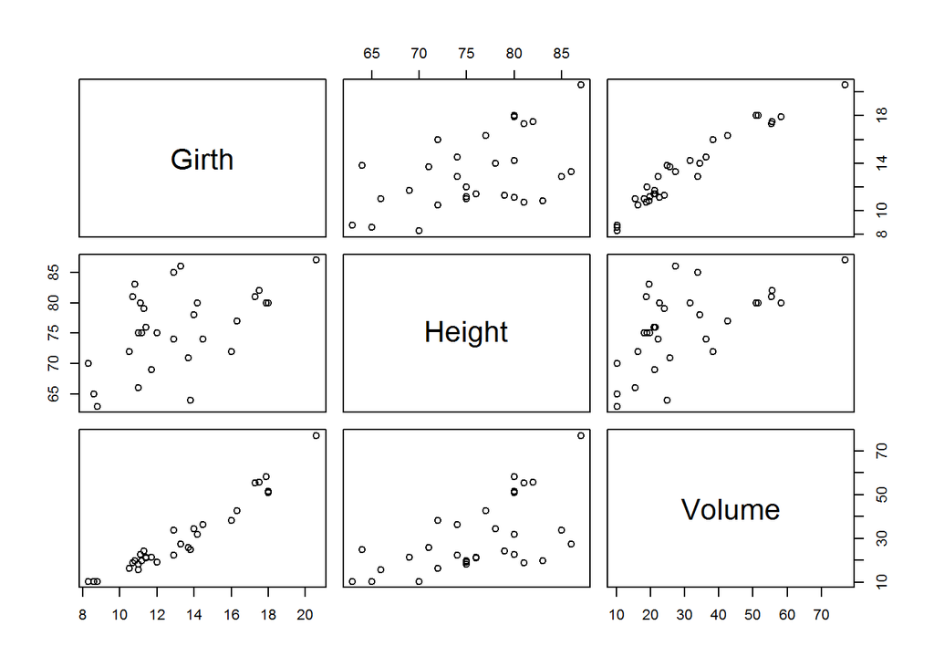

```r
plot(trees)
```

Not getting this correctly :

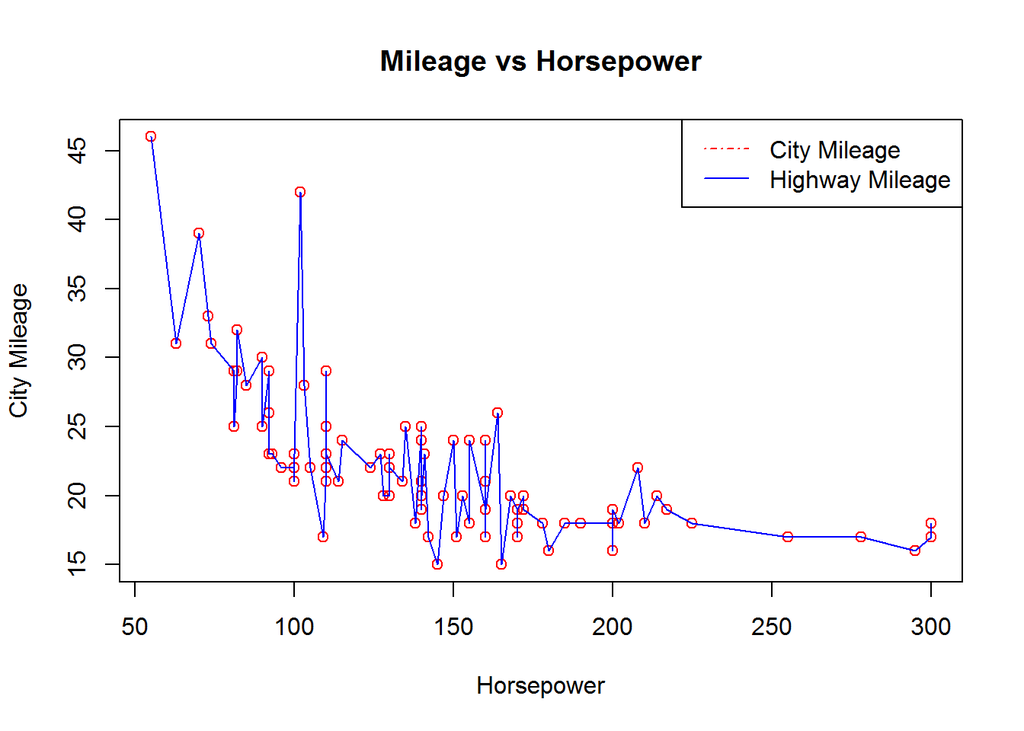

```r
attach(Cars93)
Cars93_ordered <- Cars93[order(Horsepower),]
detach(Cars93)
plot(Cars93_ordered$Horsepower, Cars93_ordered$MPG.city, col = "red", lty = 4, ann = F)
lines(Cars93_ordered$Horsepower, Cars93_ordered$MPG.city, col = "blue",lwd = 1, ann = F)
legend("topright", legend = c("City Mileage", "Highway Mileage"), lty = c(4,1), col = c("red", "blue"))
title(main = "Mileage vs Horsepower", xlab = "Horsepower", y = "City Mileage")
```

Trying using ggplot

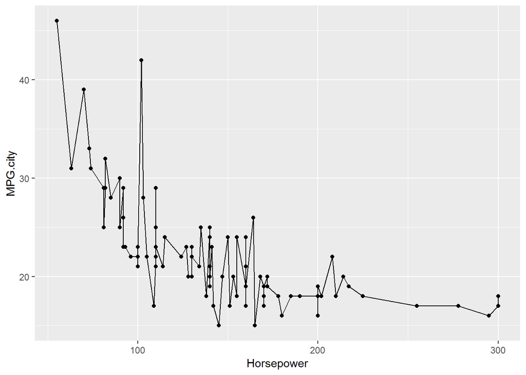

```r
ggplot(data = Cars93_ordered) +
  geom_point(aes(x = Horsepower, y = MPG.city)) +
  geom_line(aes(x = Horsepower, y = MPG.city))
```

```r
library(ggplot2)
```

```r
rm(list = ls())
data(WorldPhones)
df <- WorldPhones  # Is loaded as matrix change to data.frame
head(df)
```

```
##      N.Amer Europe Asia S.Amer Oceania Africa Mid.Amer
## 1951  45939  21574 2876   1815    1646     89      555
## 1956  60423  29990 4708   2568    2366   1411      733
## 1957  64721  32510 5230   2695    2526   1546      773
## 1958  68484  35218 6662   2845    2691   1663      836
## 1959  71799  37598 6856   3000    2868   1769      911
## 1960  76036  40341 8220   3145    3054   1905     1008
```

```r
class(df)
```

```
## [1] "matrix"
```

```r
df <- data.frame(df)
class(df)
```

```
## [1] "data.frame"
```

```r
df$Years <- as.numeric(rownames(df))
df$Years
```

```
## [1] 1951 1956 1957 1958 1959 1960 1961
```

```r
df <- subset(df, select = c("Years" ,"N.Amer", "Asia", "Europe"))
colnames(df)
```

```
## [1] "Years"  "N.Amer" "Asia"   "Europe"
```

As we need only 3 countries so melt the above data frame to use only 3 countries and put it in one column along with values in different column

```r
df_melt <- melt(df, id = c("Years"))
head(df_melt)
```

```
##   Years variable value
## 1  1951   N.Amer 45939
## 2  1956   N.Amer 60423
## 3  1957   N.Amer 64721
## 4  1958   N.Amer 68484
## 5  1959   N.Amer 71799
## 6  1960   N.Amer 76036
```

```r
colnames(df_melt) <- c("Years", "Countries", "NoOfPhones")
colnames(df_melt)
```

```
## [1] "Years"      "Countries"  "NoOfPhones"
```

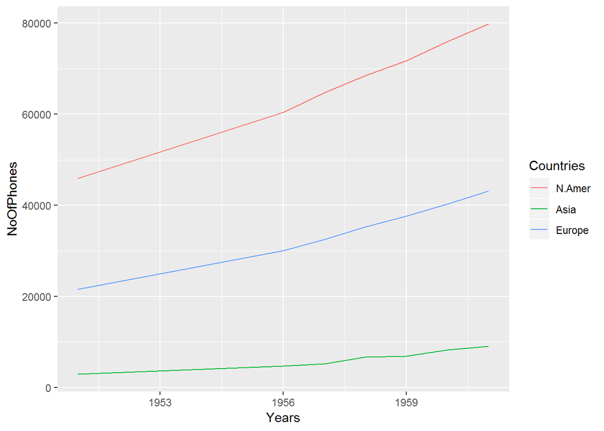

```r
ggplot(data = df_melt, aes(x = Years, y = NoOfPhones, group = Countries, colour = Countries)) +
  geom_line()
```

```r
rm(list = ls())
library(MASS)
attach(Cars93)
df <- Cars93
```

```r
head(df)
```

```
##   Manufacturer   Model    Type Min.Price Price Max.Price MPG.city
## 1        Acura Integra   Small      12.9  15.9      18.8       25
## 2        Acura  Legend Midsize      29.2  33.9      38.7       18
## 3         Audi      90 Compact      25.9  29.1      32.3       20
## 4         Audi     100 Midsize      30.8  37.7      44.6       19
## 5          BMW    535i Midsize      23.7  30.0      36.2       22
## 6        Buick Century Midsize      14.2  15.7      17.3       22
##   MPG.highway            AirBags DriveTrain Cylinders EngineSize
## 1          31               None      Front         4        1.8
## 2          25 Driver & Passenger      Front         6        3.2
## 3          26        Driver only      Front         6        2.8
## 4          26 Driver & Passenger      Front         6        2.8
## 5          30        Driver only       Rear         4        3.5
## 6          31        Driver only      Front         4        2.2
##   Horsepower  RPM Rev.per.mile Man.trans.avail Fuel.tank.capacity
```

[output cut: 20 more lines]

### dot plot

is a representation of distribution of a group of data points plotted on a simple scale.

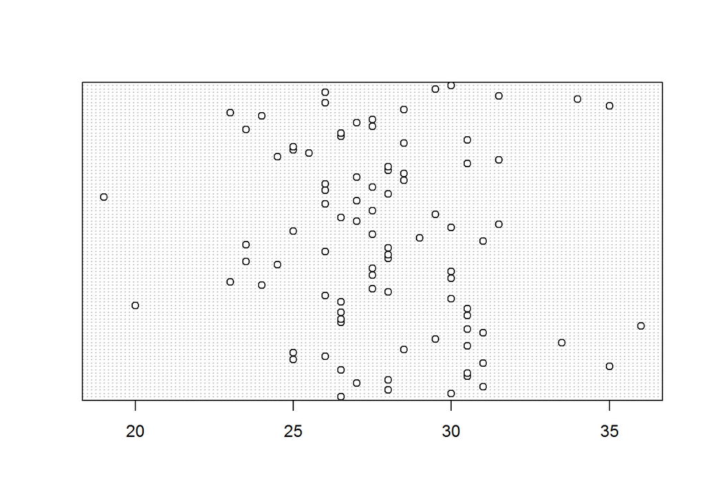

```r
dotchart(df$Rear.seat.room)
```

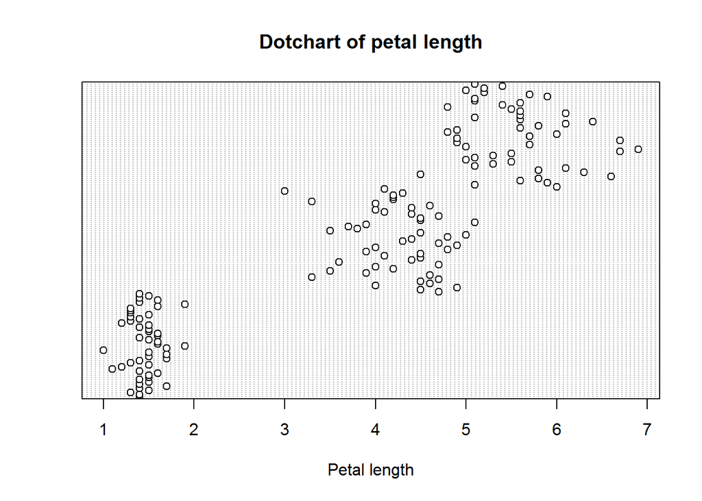

```r
dotchart(iris$Petal.Length)
title(xlab = "Petal length", main = "Dotchart of petal length")
```

## Bar Plot

```r
library(RColorBrewer)
# to use predefined color schemes from this package
```

Let us now find pattern between type of car and its seating capacity. For this purpose, we will use bar chart or bar graph, which is a chart that presents grouped data with rectangular bars with lengths proportional to the values that they represent.

```r
table_a <- table(df$Type, df$Passengers)
class(table_a)
```

```
## [1] "table"
```

```r
table_a
```

```
##
##            2  4  5  6  7  8
##   Compact  0  1 13  2  0  0
##   Large    0  0  0 11  0  0
##   Midsize  0  2 15  5  0  0
##   Small    0  8 13  0  0  0
##   Sporty   2 12  0  0  0  0
##   Van      0  0  0  0  8  1
```

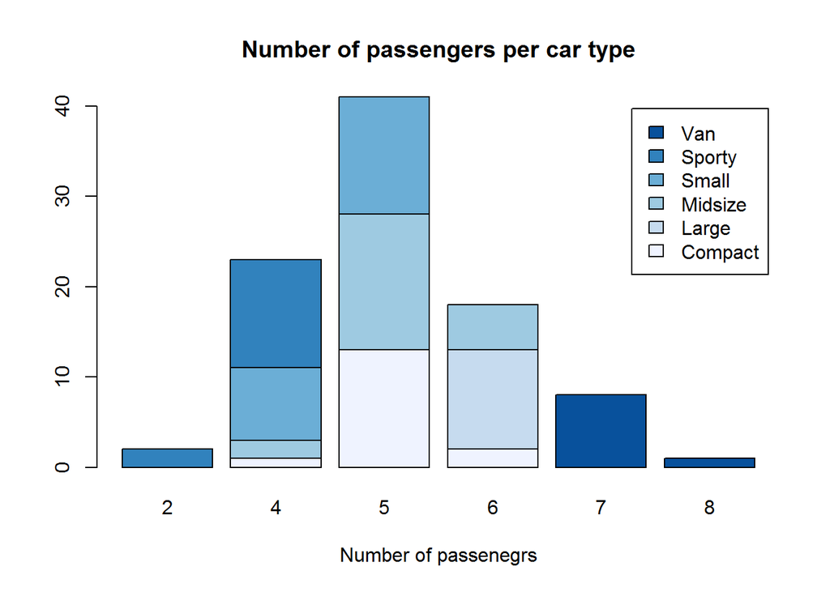

```r
barplot(table_a, legend = rownames(table_a), col = brewer.pal(6, "Blues"))
title(main = "Number of passengers per car type", xlab = "Number of passenegrs")
```

Color schemes like shown in the figure(continuous shades) should be used when we are representing continuous values.

##### So to represent discrete values using discrete color schemna

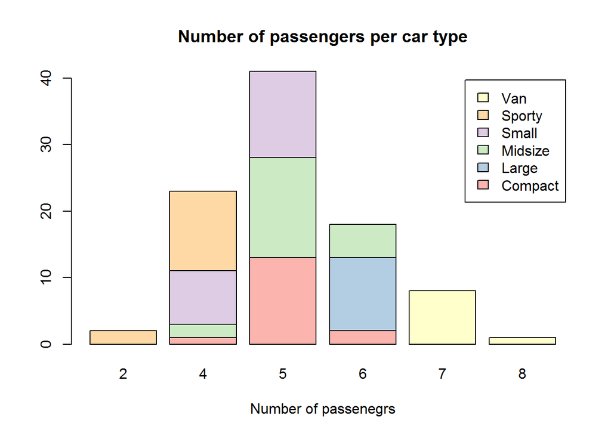

```r
barplot(table_a, legend = rownames(table_a), col = brewer.pal(6, "Pastel1"))
title(main = "Number of passengers per car type", xlab = "Number of passenegrs")
```

We observe that with the exception of few, most compact and mid size cars can accommodate 5 people. Here the height signifies the count of different car types in that passenger range.

### Stacked bargraph in ggplot2

`new_df <- data.frame(table(df$Type, df$Passengers))` when used this data frame is not coming properly so going with table

```r
table_a
```

```
##
##            2  4  5  6  7  8
##   Compact  0  1 13  2  0  0
##   Large    0  0  0 11  0  0
##   Midsize  0  2 15  5  0  0
##   Small    0  8 13  0  0  0
##   Sporty   2 12  0  0  0  0
##   Van      0  0  0  0  8  1
```

```r
new_df <- data.frame(table_a)
head(new_df)
```

```
##      Var1 Var2 Freq
## 1 Compact    2    0
## 2   Large    2    0
## 3 Midsize    2    0
## 4   Small    2    0
## 5  Sporty    2    2
## 6     Van    2    0
```

```r
colnames(new_df) <- c("CarType", "NumberOfPassenegrs", "Count")
head(new_df)
```

```
##   CarType NumberOfPassenegrs Count
## 1 Compact                  2     0
## 2   Large                  2     0
## 3 Midsize                  2     0
## 4   Small                  2     0
## 5  Sporty                  2     2
## 6     Van                  2     0
```

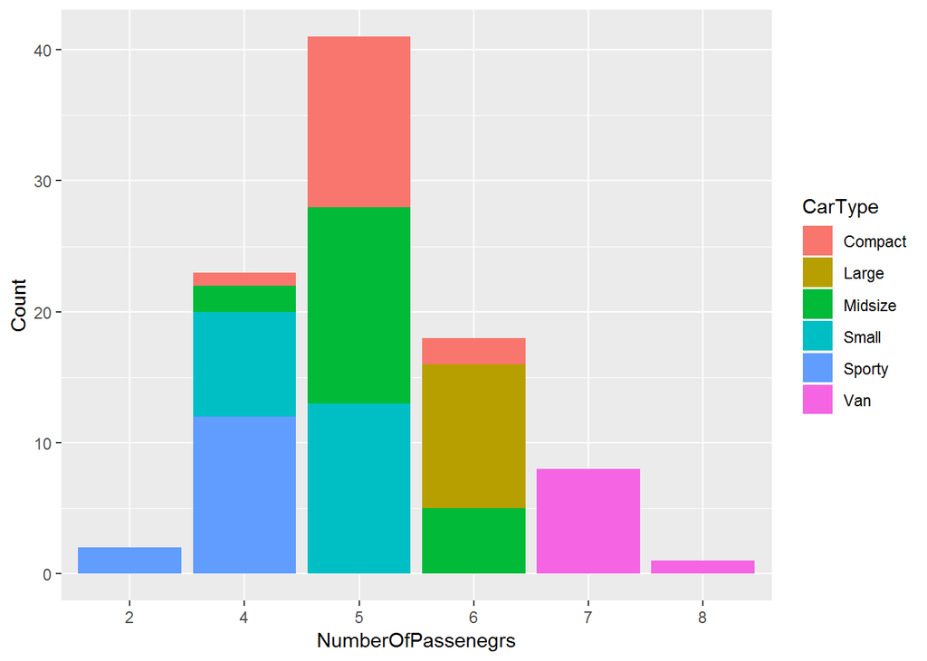

```r
ggplot(data = new_df, aes(x = NumberOfPassenegrs, y = Count, fill = CarType)) +
  geom_bar(stat = "identity")
```

```r
rm(list = ls())
library(ggplot2)
library(reshape2)
```

```r
data(WorldPhones)
df <- WorldPhones  # Is loaded as matrix change to data.frame
df <- data.frame(df)

df$Years <- as.numeric(rownames(df))
df_melt <- melt(df, id = c("Years"))
colnames(df_melt) <- c("Years", "Countries", "NoOfPhones")

head(df_melt)
```

```
##   Years Countries NoOfPhones
## 1  1951    N.Amer      45939
## 2  1956    N.Amer      60423
## 3  1957    N.Amer      64721
## 4  1958    N.Amer      68484
## 5  1959    N.Amer      71799
## 6  1960    N.Amer      76036
```

The graph below is wrong because of `stat = identity` and we had not summed up the values for different countries so need to use table().

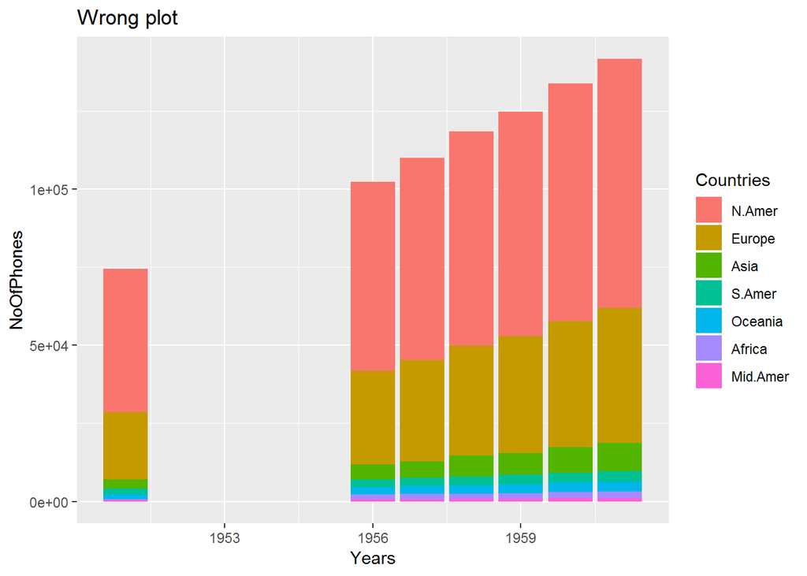

```r
ggplot(data = df_melt, aes(x = Years, y = NoOfPhones, fill = Countries)) +
  geom_bar(stat = "identity") +
  ggtitle("Wrong plot")
```

```r
ta <- table(df_melt$Years, df_melt$Countries)
ta
```

```
##
##        N.Amer Europe Asia S.Amer Oceania Africa Mid.Amer
##   1951      1      1    1      1       1      1        1
##   1956      1      1    1      1       1      1        1
##   1957      1      1    1      1       1      1        1
##   1958      1      1    1      1       1      1        1
##   1959      1      1    1      1       1      1        1
##   1960      1      1    1      1       1      1        1
##   1961      1      1    1      1       1      1        1
```

```r
library(dplyr)
df2 <- group_by(df_melt, Years, Countries)
df2
```

```
## # A tibble: 49 x 3
## # Groups:   Years, Countries [49]
##    Years Countries NoOfPhones
##    <dbl> <fct>          <dbl>
##  1  1951 N.Amer         45939
##  2  1956 N.Amer         60423
##  3  1957 N.Amer         64721
##  4  1958 N.Amer         68484
##  5  1959 N.Amer         71799
##  6  1960 N.Amer         76036
##  7  1961 N.Amer         79831
##  8  1951 Europe         21574
##  9  1956 Europe         29990
## 10  1957 Europe         32510
## # ... with 39 more rows
```

#### wrong again

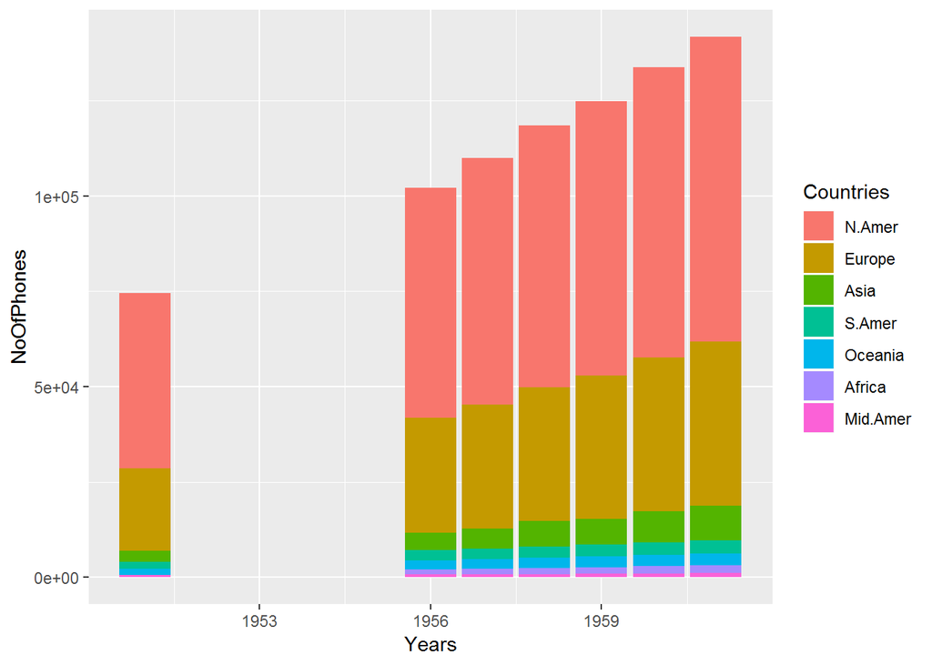

```r
ggplot(data = df2, aes(x = Years, y = NoOfPhones, fill = Countries)) +
  geom_bar(stat = "identity")
```

#### try using table as in ilpce

```r
head(df, 10)
```

```
##      N.Amer Europe Asia S.Amer Oceania Africa Mid.Amer Years
## 1951  45939  21574 2876   1815    1646     89      555  1951
## 1956  60423  29990 4708   2568    2366   1411      733  1956
## 1957  64721  32510 5230   2695    2526   1546      773  1957
## 1958  68484  35218 6662   2845    2691   1663      836  1958
## 1959  71799  37598 6856   3000    2868   1769      911  1959
## 1960  76036  40341 8220   3145    3054   1905     1008  1960
## 1961  79831  43173 9053   3338    3224   2005     1076  1961
```

```r
data(WorldPhones)
df <- WorldPhones  # Is loaded as matrix change to data.frame
df <- data.frame(df)

df$Years <- rownames(df)  # changed the years to factors again
df_melt <- melt(df, id = c("Years"))
colnames(df_melt) <- c("Years", "Countries", "NoOfPhones")

head(df_melt)
```

```
##   Years Countries NoOfPhones
## 1  1951    N.Amer      45939
## 2  1956    N.Amer      60423
## 3  1957    N.Amer      64721
## 4  1958    N.Amer      68484
## 5  1959    N.Amer      71799
## 6  1960    N.Amer      76036
```

SO the error was i put the years as numeric but for bargraph it must be as factors

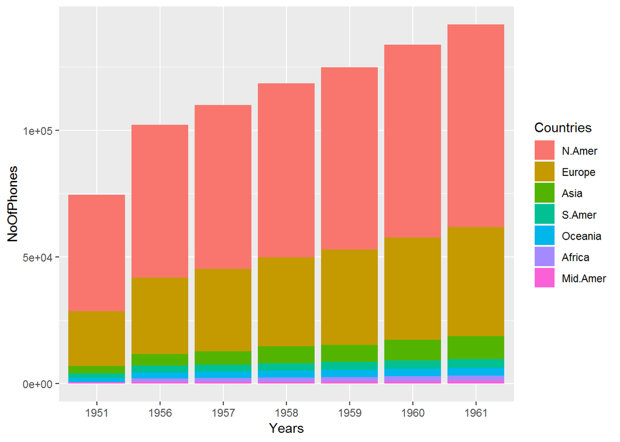

```r
ggplot(data = df_melt, aes(x = Years, y = NoOfPhones, fill = Countries)) +
  geom_bar(stat = "identity")
```

##### OR

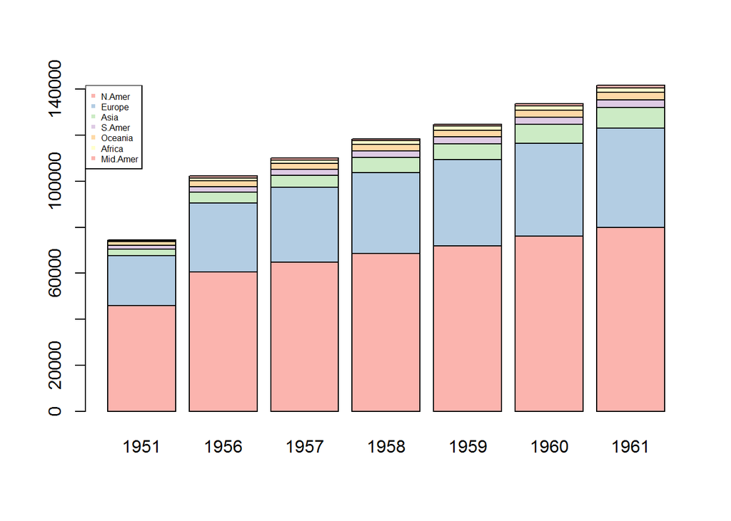

```r
library(RColorBrewer)
barplot(t(WorldPhones),  col = brewer.pal(6, "Pastel1"))
legend("topleft", legend = colnames(WorldPhones),
       col = brewer.pal(6, "Pastel1"),
       pch = 15, cex = 0.5)
```

### Histogram

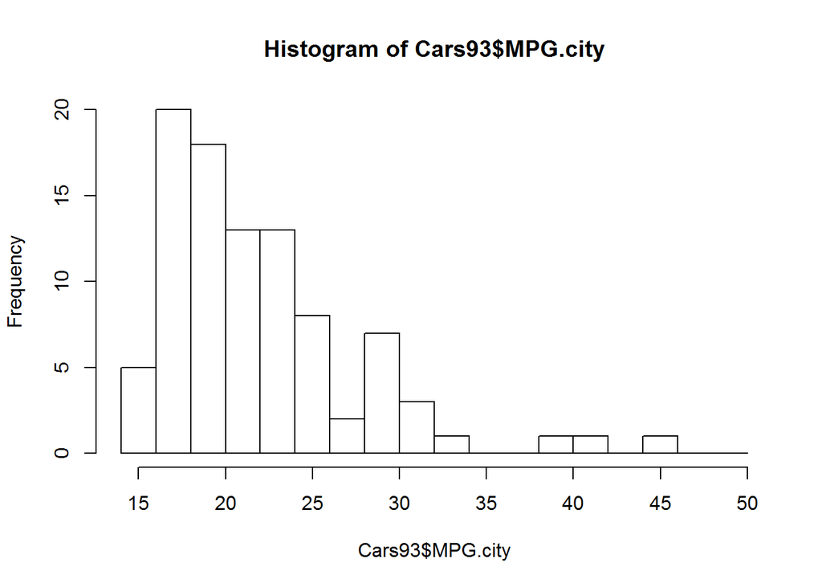

```r
rm(list = ls())
library(MASS)
data(Cars93)
hist(Cars93$MPG.city, freq = T, breaks = seq(14, 50,2))
```

**freq** if TRUE, the histogram is a representation of frequencies, else it would plot probability densities.

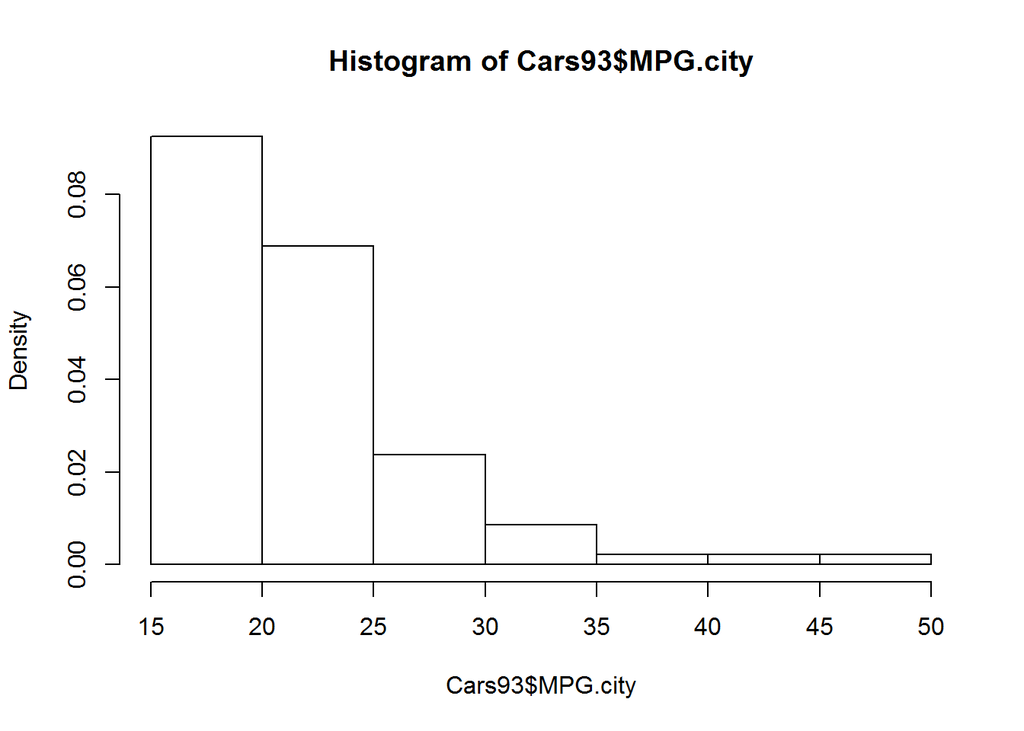

```r
hist(Cars93$MPG.city, freq = F)
```

If we want to draw a probability density plot, then using the density() and lines() we can overlay probability density curve also as seen in Probability Distribution course.

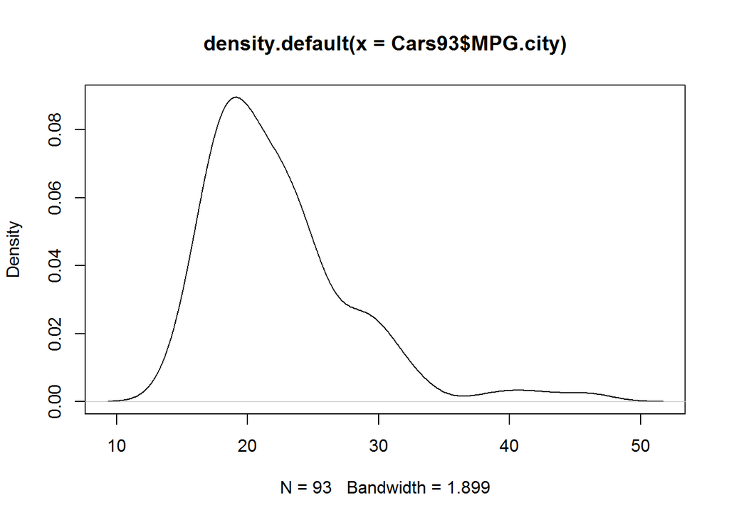

```r
plot(density(Cars93$MPG.city))
lines(Cars93$MPG.city)
```

***

## Stem and Leaf Chart

```r
stem(Cars93$MPG.city)
```

```
##
##   The decimal point is 1 digit(s) to the right of the |
##
##   1 | 55666777777778888888888889999999999
##   2 | 0000000011111122222223333333344444
##   2 | 5555556688999999
##   3 | 01123
##   3 | 9
##   4 | 2
##   4 | 6
```

### BOxplot

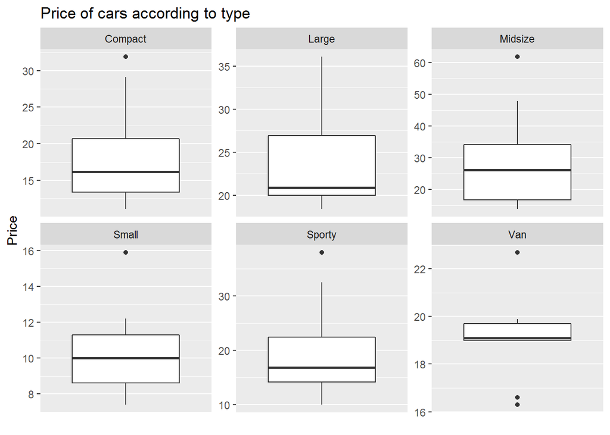

```r
ggplot() +
  geom_boxplot(data = Cars93, aes(factor(0), Price)) +
  facet_wrap(~Type, scales = "free") +
  scale_x_discrete(breaks = NULL) +
  xlab("") +
  ggtitle("Price of cars according to type")
```

## Pie chart

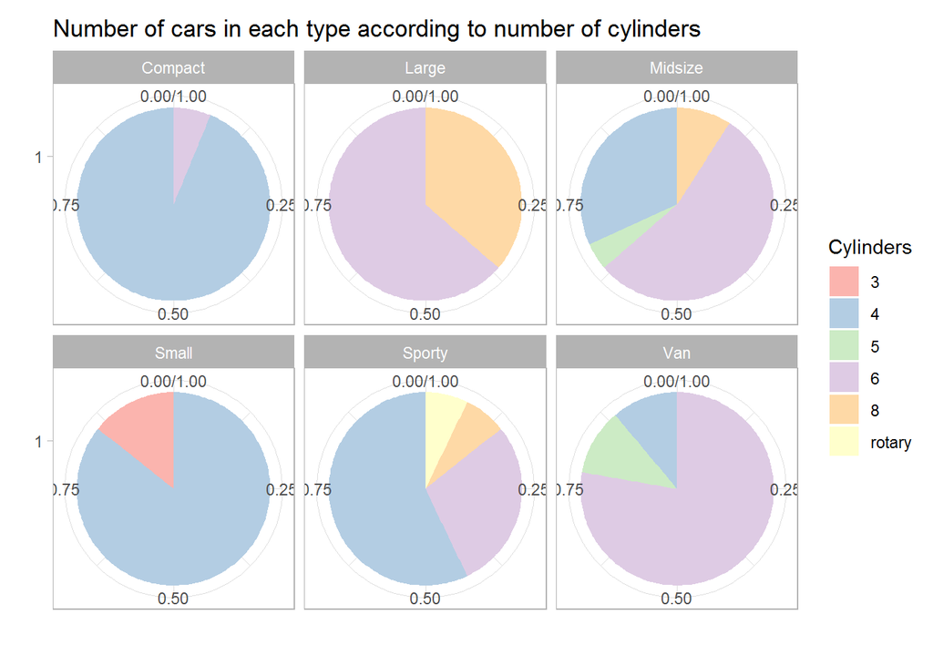

```r
ggplot() +
  geom_bar(data = Cars93, aes(x = factor(1), fill = Cylinders), width = 1, position = "fill") +
  xlab("") +
  ylab("") +
  coord_polar(theta = "y") +
  facet_wrap(~Type) +
  scale_fill_brewer(type = "qual", palette = "Pastel1") +
  theme_light() +
  ggtitle("Number of cars in each type according to number of cylinders")
```

```r
rm(list = ls())
```

```r
library(ggplot2)
dow_jones_index <- read.csv("dow_jones_index.data")
head(dow_jones_index)
```

```
##   quarter stock      date   open   high    low  close    volume
## 1       1    AA  1/7/2011 $15.82 $16.72 $15.78 $16.42 239655616
## 2       1    AA 1/14/2011 $16.71 $16.71 $15.64 $15.97 242963398
## 3       1    AA 1/21/2011 $16.19 $16.38 $15.60 $15.79 138428495
## 4       1    AA 1/28/2011 $15.87 $16.63 $15.82 $16.13 151379173
## 5       1    AA  2/4/2011 $16.18 $17.39 $16.18 $17.14 154387761
## 6       1    AA 2/11/2011 $17.33 $17.48 $16.97 $17.37 114691279
##   percent_change_price percent_change_volume_over_last_wk
## 1             3.792670                                 NA
## 2            -4.428490                           1.380223
## 3            -2.470660                         -43.024959
## 4             1.638310                           9.355500
## 5             5.933250                           1.987452
## 6             0.230814                         -25.712195
##   previous_weeks_volume next_weeks_open next_weeks_close
```

[output cut: 20 more lines]

```r
dow_jones_index <- subset(dow_jones_index, select = c("stock", "date", "percent_change_price", "percent_change_volume_over_last_wk"),
                          subset = dow_jones_index$stock %in% c("BAC", "AXP"))

dow_jones_index[, "date"] <- as.Date(dow_jones_index[, "date"], "%m/%d/%Y")
head(dow_jones_index)
```

```
##    stock       date percent_change_price
## 13   AXP 2011-01-07            2.4480400
## 14   AXP 2011-01-14            4.6380100
## 15   AXP 2011-01-21           -0.0651749
## 16   AXP 2011-01-28           -4.7557000
## 17   AXP 2011-02-04           -0.7024700
## 18   AXP 2011-02-11            6.3466800
##    percent_change_volume_over_last_wk
## 13                                 NA
## 14                          -42.54426
## 15                           49.82310
## 16                           32.46010
## 17                          -23.18924
## 18                           10.74718
```

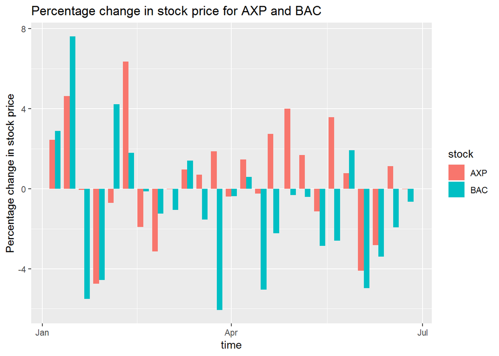

```r
a <- ggplot() +
  geom_bar(data = dow_jones_index, aes(x=date, y=percent_change_price, fill = stock), stat = "identity", position = position_dodge())

a + ggtitle("Percentage change in stock price for AXP and BAC") +
  xlab("time") + ylab("Percentage change in stock price")
```

## Stock market scenario - Bar Chart and Line Chart

```r
colnames(dow_jones_index)
```

```
## [1] "stock"
## [2] "date"
## [3] "percent_change_price"
## [4] "percent_change_volume_over_last_wk"
```

a <- ggplot() + geom_bar(data = dow_jones_index, aes(x=date, y=percent_change_price, fill = stock), stat = “identity”, position = position_dodge()) + geom_line(aes(x = date, y = percent_change_volume_over_last_wk, col = stock))

a + ggtitle(“Percentage change in stock price for AXP and BAC”) + xlab(“time”) + ylab(“Percentage change in stock price”)

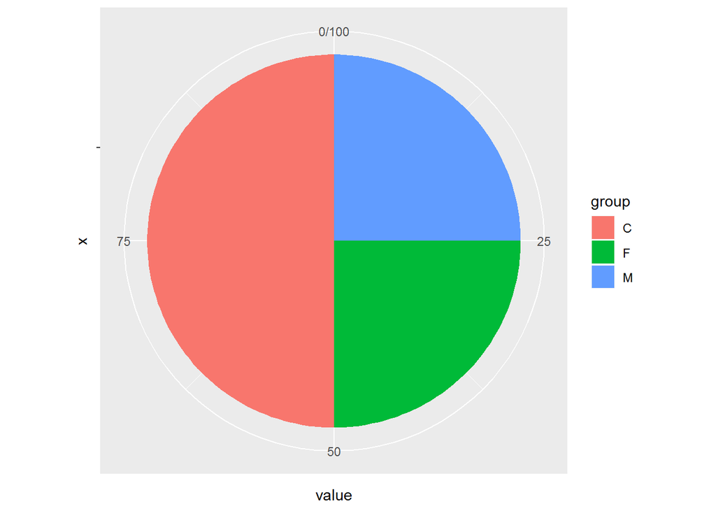

```r
rm(list = ls())
df <- data.frame(
  group <- c("M", "F", "C"),
  value <- c(25,25, 50)
)

ggplot(df, aes(x = "", y = value, fill = group)) +
  geom_bar(width = 1, stat = "identity") +
  coord_polar("y", start = 0)
```

A.

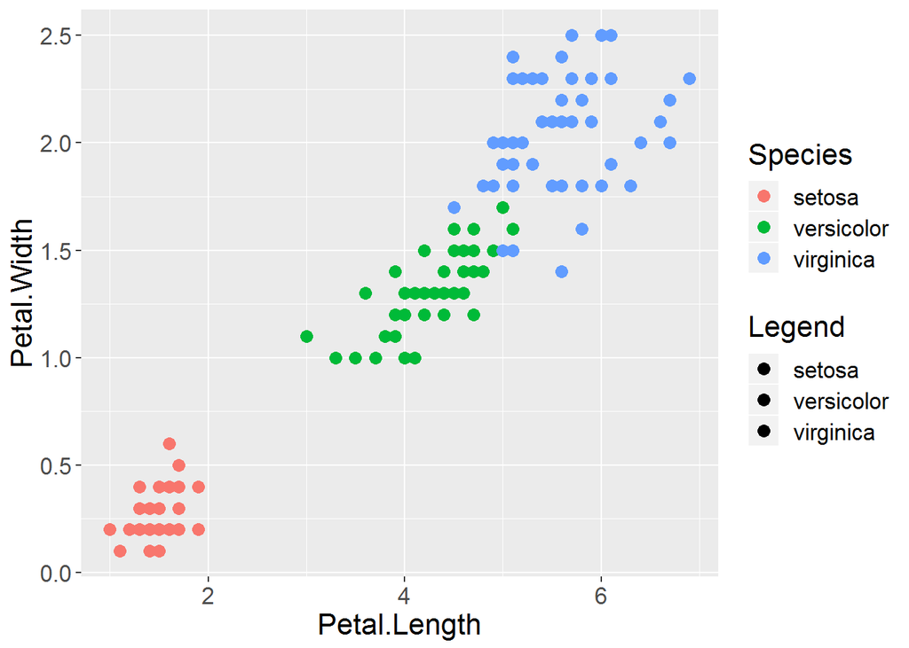

```r
ggplot() +
  geom_point(data = iris, aes(x = Petal.Length, y = Petal.Width, col=Species, fill = Species), size =3) +
  labs(fill = "Legend") + theme(text = element_text(size=16))
```

B. Correct one

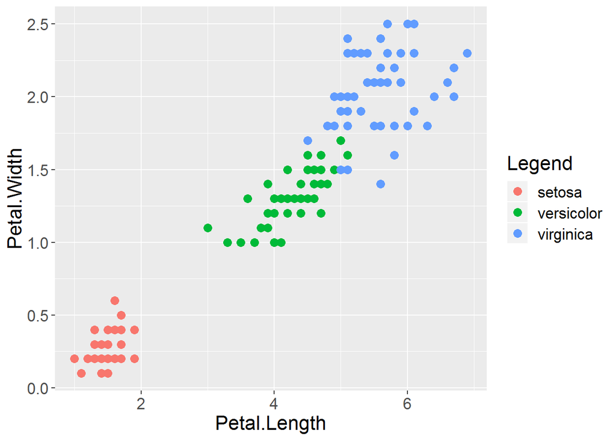

```r
ggplot() +
  geom_point(data = iris, aes(x = Petal.Length, y = Petal.Width, col=Species), size =3) +
  labs(col = "Legend") + theme(text = element_text(size=16))
```

C.

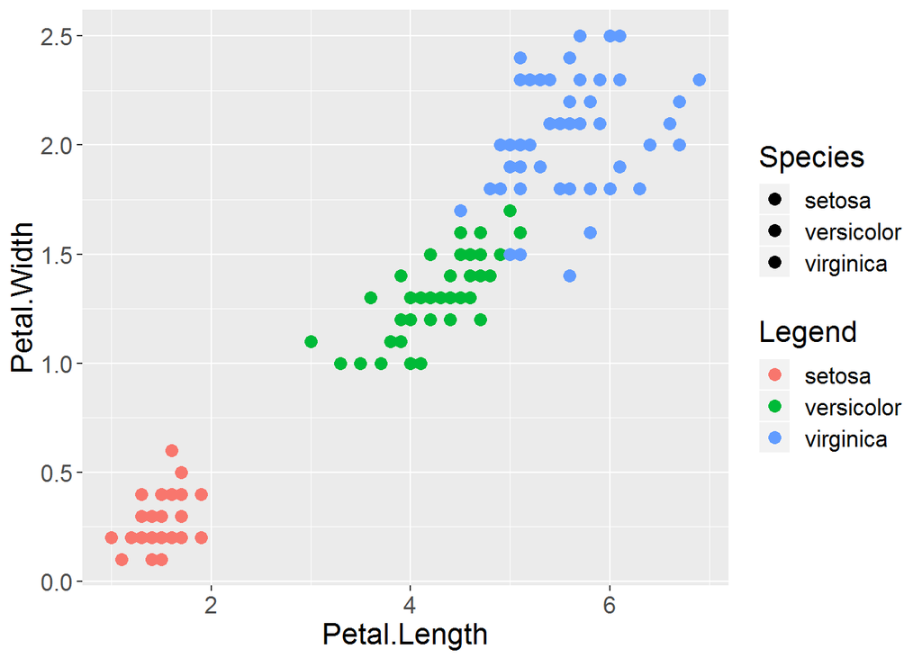

```r
ggplot() +
  geom_point(data = iris, aes(x = Petal.Length, y = Petal.Width, col=Species, fill = Species), size =3) +
  labs(col = "Legend") + theme(text = element_text(size=16))
```

D. Correct

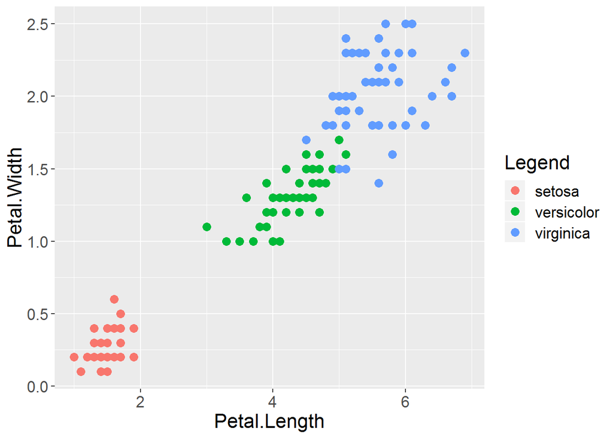

```r
ggplot() +
  geom_point(data = iris, aes(x = Petal.Length, y = Petal.Width, col=Species, fill = Species), size =3) +
  labs(col = "Legend", fill = "Legend") + theme(text = element_text(size=16))
```